# Analysis of longitudinal and repeated measures data

Jussi Jaatinen

# Analysis of longitudinal and repeated measures data

If the same person makes several observations in same experiment or the weight of the same animal is measured several times during the longer time or in different conditions, those measurements are hardly independent. This must be also taken into account in analysis models of such kind of data.

Two such kind of datasets are wrangled and analyzed in this excercise. First set, RATS, includes information about different nutritions and their influence to the weight of rats during 9 weeks period. In the second set, BPRS, 40 male subjects were randomly assigned to two groups and each subject was rated on the brief psychiatric rating scale (BPRS) measured before treatment and then at weekly intervals for eight weeks.The scale is used to evaluate patients suspected of having schizophrenia.

Both datasets have been converted to long form for analyses.

## RATS dataframe

Here is the original RATS dataframe and same data wrangled to long form with class changes. Variables ID and Group have been changed to factor type. As seen in tables, structure of dataframes are quite different, although they include the same information. A new variable “time” has been added to long form dataframe, RATSL. It is extracted from variable “WD” by picking only numbers and changing class to integer.

```
Observations: 16
Variables: 13
$ ID    <int> 1, 2, 3, 4, 5, 6, 7, 8, 9, 10, 11, 12, 13, 14, 15, 16
$ Group <int> 1, 1, 1, 1, 1, 1, 1, 1, 2, 2, 2, 2, 3, 3, 3, 3
$ WD1   <int> 240, 225, 245, 260, 255, 260, 275, 245, 410, 405, 445, 5...
$ WD8   <int> 250, 230, 250, 255, 260, 265, 275, 255, 415, 420, 445, 5...
$ WD15  <int> 255, 230, 250, 255, 255, 270, 260, 260, 425, 430, 450, 5...
$ WD22  <int> 260, 232, 255, 265, 270, 275, 270, 268, 428, 440, 452, 5...
$ WD29  <int> 262, 240, 262, 265, 270, 275, 273, 270, 438, 448, 455, 5...
$ WD36  <int> 258, 240, 265, 268, 273, 277, 274, 265, 443, 460, 455, 5...
$ WD43  <int> 266, 243, 267, 270, 274, 278, 276, 265, 442, 458, 451, 5...
$ WD44  <int> 266, 244, 267, 272, 273, 278, 271, 267, 446, 464, 450, 5...
$ WD50  <int> 265, 238, 264, 274, 276, 284, 282, 273, 456, 475, 462, 6...
$ WD57  <int> 272, 247, 268, 273, 278, 279, 281, 274, 468, 484, 466, 6...
$ WD64  <int> 278, 245, 269, 275, 280, 281, 284, 278, 478, 496, 472, 6...
```

```
Observations: 176
Variables: 5
$ ID     <fct> 1, 2, 3, 4, 5, 6, 7, 8, 9, 10, 11, 12, 13, 14, 15, 16, ...
$ Group  <fct> 1, 1, 1, 1, 1, 1, 1, 1, 2, 2, 2, 2, 3, 3, 3, 3, 1, 1, 1...
$ WD     <chr> "WD1", "WD1", "WD1", "WD1", "WD1", "WD1", "WD1", "WD1",...
$ Weight <int> 240, 225, 245, 260, 255, 260, 275, 245, 410, 405, 445, ...
$ Time   <int> 1, 1, 1, 1, 1, 1, 1, 1, 1, 1, 1, 1, 1, 1, 1, 1, 8, 8, 8...
```

### Plot of the RATSL data

Here each individual rat has separate curves and three groups have marked with different line types.

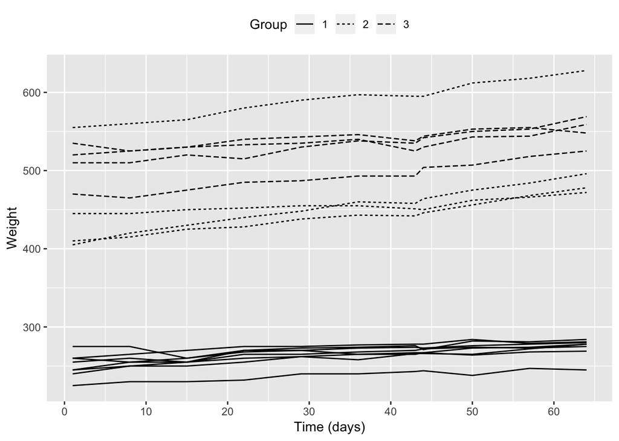

#### Normal linear regression model (not for repeated measures)

This is a normal linear model analysis without any interactions or random variables.

```
Call:
lm(formula = RATSL$Weight ~ RATSL$Time + RATSL$Group, data = RATSL)

Residuals:
    Min      1Q  Median      3Q     Max
-60.643 -24.017   0.697  10.837 125.459

Coefficients:
             Estimate Std. Error t value Pr(>|t|)
(Intercept)  244.0689     5.7725  42.281  < 2e-16 ***
RATSL$Time     0.5857     0.1331   4.402 1.88e-05 ***
RATSL$Group2 220.9886     6.3402  34.855  < 2e-16 ***
RATSL$Group3 262.0795     6.3402  41.336  < 2e-16 ***
---
Signif. codes:  0 '***' 0.001 '**' 0.01 '*' 0.05 '.' 0.1 ' ' 1

Residual standard error: 34.34 on 172 degrees of freedom
Multiple R-squared:  0.9283,    Adjusted R-squared:  0.9271
F-statistic: 742.6 on 3 and 172 DF,  p-value: < 2.2e-16
```

#### Random intercept model

Here a random variable intercept (1 | ID) has been added and Linear Mixed Effects Regression model analysis (lmer function) has been executed. This means that individual differences in intercepts between subjects have been taken into account as an random variable. In results we can see that all fixed effects are significant.

```
Linear mixed model fit by maximum likelihood  ['lmerMod']
Formula: Weight ~ Time + Group + (1 | ID)
   Data: RATSL

     AIC      BIC   logLik deviance df.resid
  1333.2   1352.2   -660.6   1321.2      170

Scaled residuals:
    Min      1Q  Median      3Q     Max
-3.5386 -0.5581 -0.0494  0.5693  3.0990

Random effects:
 Groups   Name        Variance Std.Dev.
 ID       (Intercept) 1085.92  32.953
 Residual               66.44   8.151
Number of obs: 176, groups:  ID, 16

Fixed effects:
             Estimate Std. Error t value
(Intercept) 244.06890   11.73107   20.80
Time          0.58568    0.03158   18.54
Group2      220.98864   20.23577   10.92
Group3      262.07955   20.23577   12.95

Correlation of Fixed Effects:
       (Intr) Time   Group2
Time   -0.090
Group2 -0.575  0.000
Group3 -0.575  0.000  0.333
```

#### Random slope model

Here is another model with random slope model (Time | ID).

```
Linear mixed model fit by maximum likelihood  ['lmerMod']
Formula: Weight ~ Time + Group + (Time | ID)
   Data: RATSL

     AIC      BIC   logLik deviance df.resid
  1194.2   1219.6   -589.1   1178.2      168

Scaled residuals:
    Min      1Q  Median      3Q     Max
-3.2261 -0.4322  0.0555  0.5638  2.8827

Random effects:
 Groups   Name        Variance  Std.Dev. Corr
 ID       (Intercept) 1140.5363 33.7718
          Time           0.1122  0.3349  -0.22
 Residual               19.7456  4.4436
Number of obs: 176, groups:  ID, 16

Fixed effects:
             Estimate Std. Error t value
(Intercept) 246.45727   11.81526  20.859
Time          0.58568    0.08548   6.852
Group2      214.58736   20.17983  10.634
Group3      258.92732   20.17983  12.831

Correlation of Fixed Effects:
       (Intr) Time   Group2
Time   -0.166
Group2 -0.569  0.000
Group3 -0.569  0.000  0.333
```

#### ANOVA of “Random slope model” and “Random intercept model”

Here we can see results of ANOVA for two aforementioned models. Here we can see that due to Chi<sup>2</sup> test, there is a significant difference between these two models.

```
Data: RATSL
Models:
RATS_ref: Weight ~ Time + Group + (1 | ID)
RATS_ref1: Weight ~ Time + Group + (Time | ID)
          Df    AIC    BIC  logLik deviance  Chisq Chi Df Pr(>Chisq)
RATS_ref   6 1333.2 1352.2 -660.58   1321.2
RATS_ref1  8 1194.2 1219.6 -589.11   1178.2 142.94      2  < 2.2e-16 ***
---
Signif. codes:  0 '***' 0.001 '**' 0.01 '*' 0.05 '.' 0.1 ' ' 1
```

#### Random slope model with the interaction

And here is another random variable (Time | Group) added.

```
Linear mixed model fit by maximum likelihood  ['lmerMod']
Formula: Weight ~ Time + Group + (Time | ID) + (Time | Group)
   Data: RATSL

     AIC      BIC   logLik deviance df.resid
  1195.8   1230.7   -586.9   1173.8      165

Scaled residuals:
    Min      1Q  Median      3Q     Max
-3.2547 -0.4134  0.0710  0.5961  2.7906

Random effects:
 Groups   Name        Variance  Std.Dev. Corr
 ID       (Intercept) 1.114e+03 33.3728
          Time        6.141e-02  0.2478  -0.16
 Group    (Intercept) 2.646e+01  5.1439
          Time        5.006e-02  0.2237  -1.00
 Residual             1.975e+01  4.4436
Number of obs: 176, groups:  ID, 16; Group, 3

Fixed effects:
            Estimate Std. Error t value
(Intercept) 245.0357    12.1221  20.214
Time          0.6474     0.1456   4.447
Group2      214.5926    20.1799  10.634
Group3      258.9301    20.1799  12.831

Correlation of Fixed Effects:
       (Intr) Time   Group2
Time   -0.276
Group2 -0.555  0.000
Group3 -0.555  0.000  0.333
```

#### ANOVA of “Random slope model with interaction” and “Random slope model”

Here again ANOVA for two latest models. Due to Chi^2 test, there is no significant difference between these two models.

```
Data: RATSL
Models:
RATS_ref1: Weight ~ Time + Group + (Time | ID)
RATS_ref2: Weight ~ Time + Group + (Time | ID) + (Time | Group)
          Df    AIC    BIC  logLik deviance  Chisq Chi Df Pr(>Chisq)
RATS_ref1  8 1194.2 1219.6 -589.11   1178.2
RATS_ref2 11 1195.8 1230.7 -586.92   1173.8 4.3719      3      0.224
```

#### Plot of RATSL with the observed Weight values

Comparison of observed and fitted weight values.

Observed values

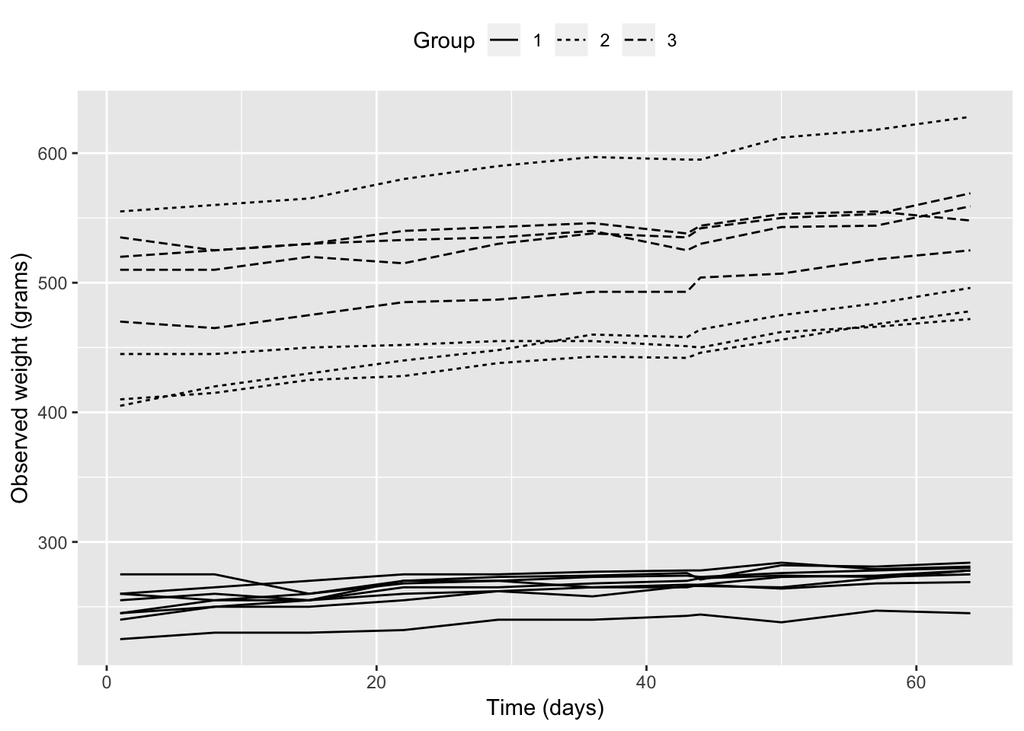

#### Plot of RATSL with the Fitted values of weight

Fitted values

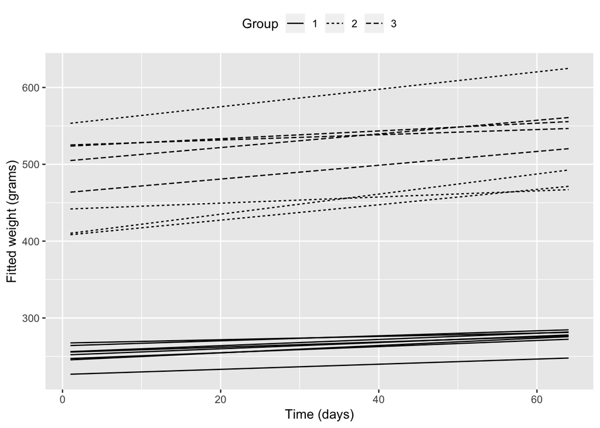

## BPRS dataframe

As well as in RATS dataframe same data wrangling to long form with class changes has been made. Variables “treatment” and “subject” have been changed to factor type. As seen in tables, structure of dataframes are quite different, although they include the same information. Also here, a new integer variable “week” has been added to long form dataframe, BPRSL.

```
Observations: 40
Variables: 11
$ treatment <int> 1, 1, 1, 1, 1, 1, 1, 1, 1, 1, 1, 1, 1, 1, 1, 1, 1, 1...
$ subject   <int> 1, 2, 3, 4, 5, 6, 7, 8, 9, 10, 11, 12, 13, 14, 15, 1...
$ week0     <int> 42, 58, 54, 55, 72, 48, 71, 30, 41, 57, 30, 55, 36, ...
$ week1     <int> 36, 68, 55, 77, 75, 43, 61, 36, 43, 51, 34, 52, 32, ...
$ week2     <int> 36, 61, 41, 49, 72, 41, 47, 38, 39, 51, 34, 49, 36, ...
$ week3     <int> 43, 55, 38, 54, 65, 38, 30, 38, 35, 55, 41, 54, 31, ...
$ week4     <int> 41, 43, 43, 56, 50, 36, 27, 31, 28, 53, 36, 48, 25, ...
$ week5     <int> 40, 34, 28, 50, 39, 29, 40, 26, 22, 43, 36, 43, 25, ...
$ week6     <int> 38, 28, 29, 47, 32, 33, 30, 26, 20, 43, 38, 37, 21, ...
$ week7     <int> 47, 28, 25, 42, 38, 27, 31, 25, 23, 39, 36, 36, 19, ...
$ week8     <int> 51, 28, 24, 46, 32, 25, 31, 24, 21, 32, 36, 31, 22, ...
```

```
Observations: 360
Variables: 5
$ treatment <fct> 1, 1, 1, 1, 1, 1, 1, 1, 1, 1, 1, 1, 1, 1, 1, 1, 1, 1...
$ subject   <fct> 1, 2, 3, 4, 5, 6, 7, 8, 9, 10, 11, 12, 13, 14, 15, 1...
$ weeks     <chr> "week0", "week0", "week0", "week0", "week0", "week0"...
$ bprs      <int> 42, 58, 54, 55, 72, 48, 71, 30, 41, 57, 30, 55, 36, ...
$ week      <int> 0, 0, 0, 0, 0, 0, 0, 0, 0, 0, 0, 0, 0, 0, 0, 0, 0, 0...
```

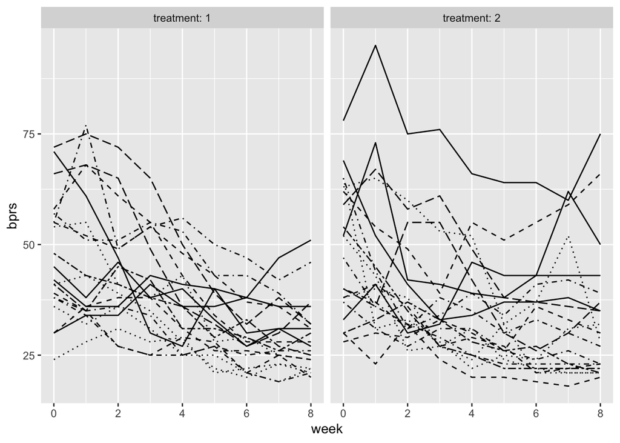

#### Standardization of the variable “bprs”

Here, variable “bprs” has been standardized and the new variable “stdbprs” has been created and added to BPRSL dataframe. Men who have higher BPRS values at the beginning seem to have higher values throughout the study.

```
Observations: 360
Variables: 6
$ treatment <fct> 1, 1, 1, 1, 1, 1, 1, 1, 1, 1, 1, 1, 1, 1, 1, 1, 1, 1...
$ subject   <fct> 1, 2, 3, 4, 5, 6, 7, 8, 9, 10, 11, 12, 13, 14, 15, 1...
$ weeks     <chr> "week0", "week0", "week0", "week0", "week0", "week0"...
$ bprs      <int> 42, 58, 54, 55, 72, 48, 71, 30, 41, 57, 30, 55, 36, ...
$ week      <int> 0, 0, 0, 0, 0, 0, 0, 0, 0, 0, 0, 0, 0, 0, 0, 0, 0, 0...
$ stdbprs   <dbl> -0.4245908, 0.7076513, 0.4245908, 0.4953559, 1.69836...
```

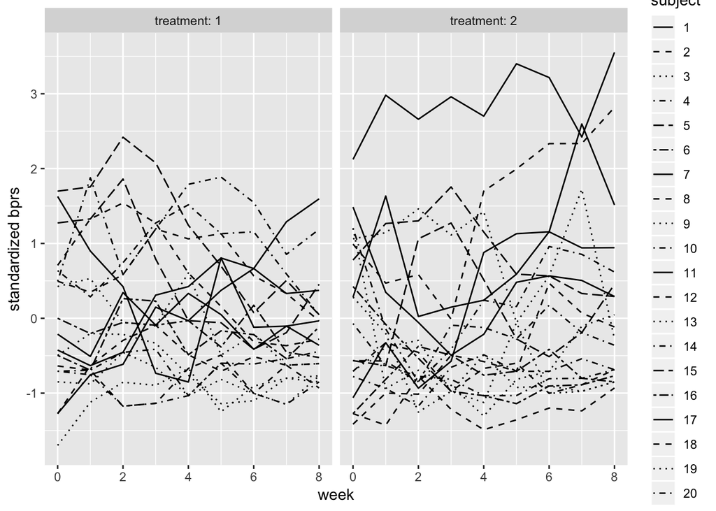

#### Means and standard errors

Means (over all subjects) and standard errors have been calculated. In the figure below differences between treatments can be seen. Due to confidental intervals are overlapping, probability to statistically significant difference is weak.

```
Observations: 18
Variables: 4
$ treatment <fct> 1, 1, 1, 1, 1, 1, 1, 1, 1, 2, 2, 2, 2, 2, 2, 2, 2, 2
$ week      <int> 0, 1, 2, 3, 4, 5, 6, 7, 8, 0, 1, 2, 3, 4, 5, 6, 7, 8
$ mean      <dbl> 47.00, 46.80, 43.55, 40.90, 36.60, 32.70, 29.70, 29....
$ se        <dbl> 4.534468, 5.173708, 4.003617, 3.744626, 3.259534, 2....
```

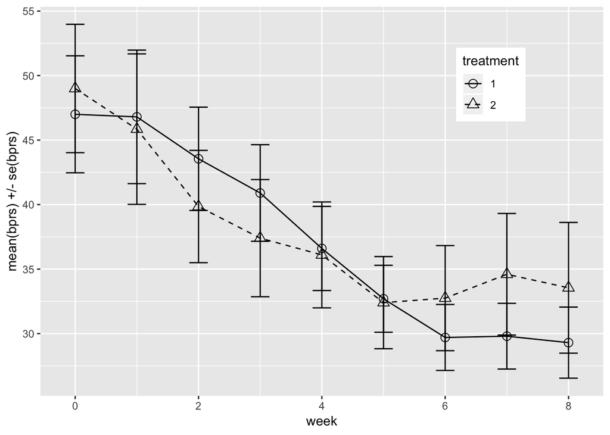

#### Boxplot of the mean versus treatment

Here is boxplot of both treatment groups.

```
Observations: 40
Variables: 3
$ treatment <fct> 1, 1, 1, 1, 1, 1, 1, 1, 1, 1, 1, 1, 1, 1, 1, 1, 1, 1...
$ subject   <fct> 1, 2, 3, 4, 5, 6, 7, 8, 9, 10, 11, 12, 13, 14, 15, 1...
$ mean      <dbl> 41.500, 43.125, 35.375, 52.625, 50.375, 34.000, 37.1...
```

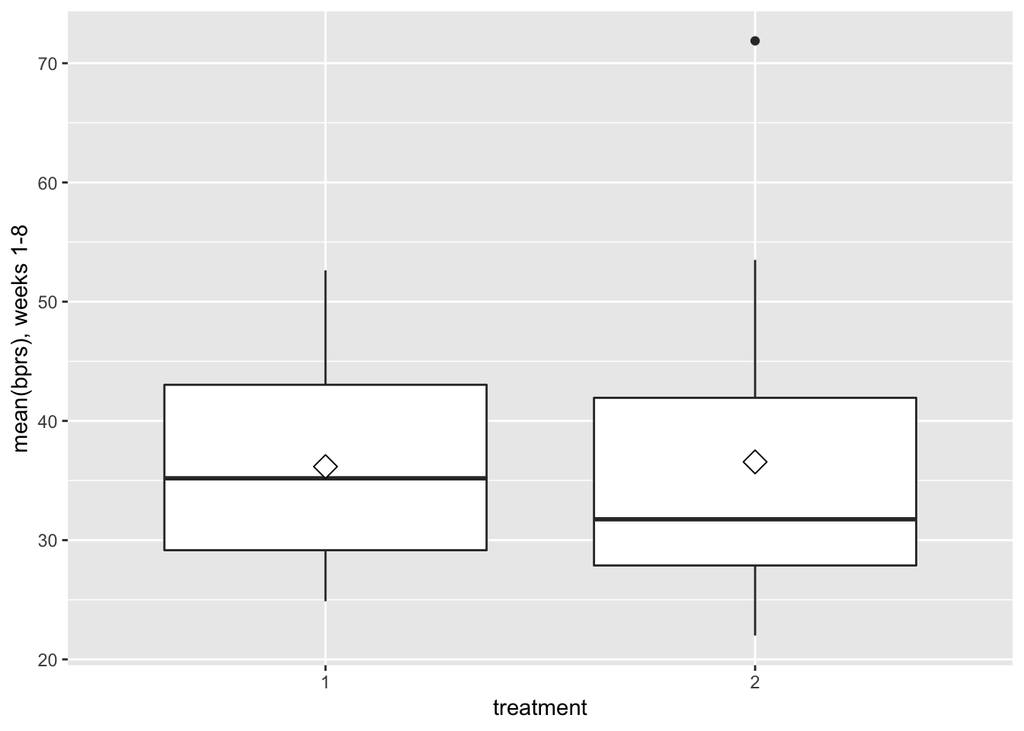

#### Outlier

Here we can see in the boxplot above an outlier, which may be an error. It also moves mean of the treatment 2 upwards. It can be removed by filtering out bprs values above 60. Below is the new boxplot with outlier removed. Mean (white square) is now closer to median (black horizontal line).

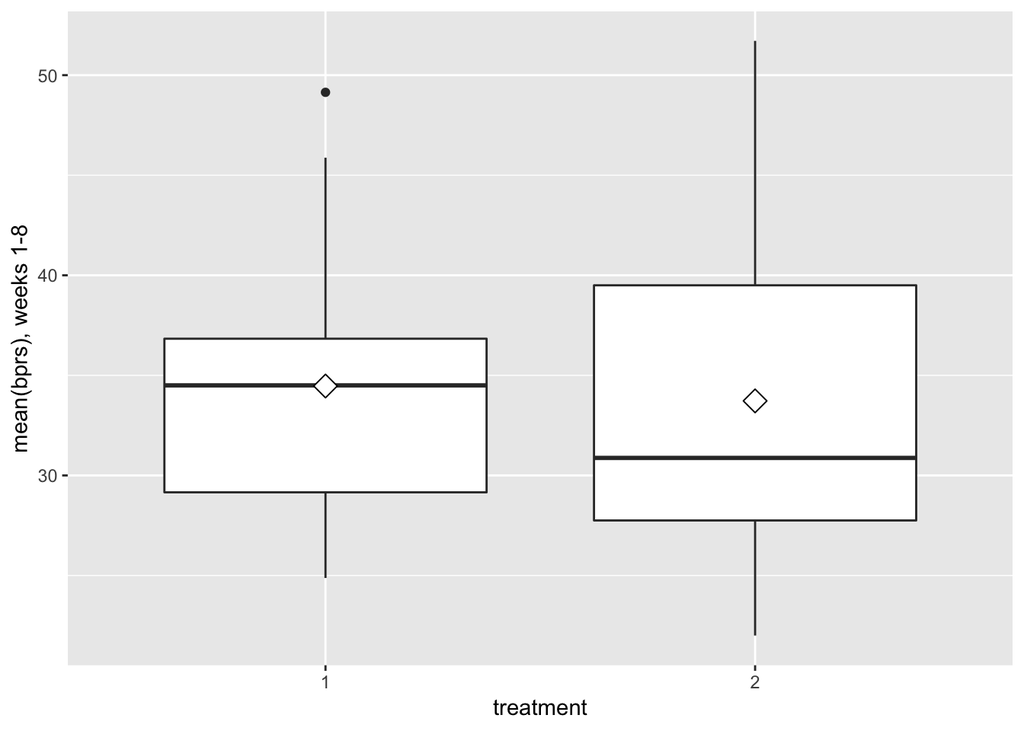

#### T-test

For testing difference between means of treatments, common two sample t-test is suitable. According to it, p value 0.75 is far from significance. That is, treatments do not have statistically significant difference.

```
    Two Sample t-test

data:  mean by treatment
t = 0.3178, df = 37, p-value = 0.7524
alternative hypothesis: true difference in means is not equal to 0
95 percent confidence interval:
 -3.996521  5.483407
sample estimates:
mean in group 1 mean in group 2
       34.46744        33.72400
```

#### Adding baseline

Here we add the baseline from the original data as a new variable to the summary data.

```
Observations: 40
Variables: 4
$ treatment <fct> 1, 1, 1, 1, 1, 1, 1, 1, 1, 1, 1, 1, 1, 1, 1, 1, 1, 1...
$ subject   <fct> 1, 2, 3, 4, 5, 6, 7, 8, 9, 10, 11, 12, 13, 14, 15, 1...
$ mean      <dbl> 41.500, 43.125, 35.375, 52.625, 50.375, 34.000, 37.1...
$ baseline  <int> 42, 58, 54, 55, 72, 48, 71, 30, 41, 57, 30, 55, 36, ...
```

#### Linear model with baseline and treatment

Here we run lm -function “mean” as target and “baseline” and “treatment” as explanatory variables.

```
Call:
lm(formula = mean ~ baseline + treatment, data = BPRSL8S2)

Coefficients:
(Intercept)     baseline   treatment2
    13.0790       0.4913      -0.5888
```

#### Anova of linear model

Even with baseline corrected, treatments have not significant difference (p = 0.81).

```
Analysis of Variance Table

Response: mean
          Df  Sum Sq Mean Sq F value    Pr(>F)
baseline   1 1868.07 1868.07 30.1437 3.077e-06 ***
treatment  1    3.45    3.45  0.0557    0.8148
Residuals 37 2292.97   61.97
---
Signif. codes:  0 '***' 0.001 '**' 0.01 '*' 0.05 '.' 0.1 ' ' 1
```